# DATA 607 - Homework #5

Zach Alexander

10/9/2019

## Libraries used:

```r
library(RCurl)
library(XML)
library(stringr)
library(htmlTable)
library(magrittr)
library(rvest)
library(dplyr)
library(knitr)
library(kableExtra)
library(jsonlite)
```

## XML Extraction

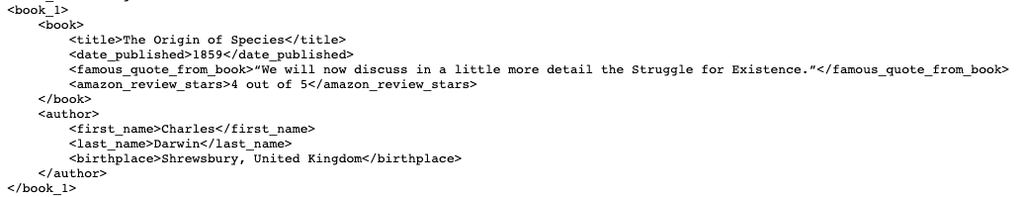

Snapshot of part of the raw XML file that I created.

#### First, I read in the raw xml file from my GitHub account

```r
books_xml_raw <- getURL('https://raw.githubusercontent.com/zachalexander/data607_cunysps/master/Homework5/books.xml')
```

#### Then, I created an empty data frame with 5 rows and 7 columns and renamed column headers

```r
books_xml_df <- data.frame(matrix(NA, nrow = 5, ncol = 7))

# renaming column headers
books_xml_df <- books_xml_df %>%
  rename("title" = X1,
         "date_pub" = X2,
         "famous_quote" = X3,
         "amazon_rating" = X4,
         "author_first_name" = X5,
         "author_last_name" = X6,
         "author_birthplace" = X7)
```

#### I decided to use regex to find the data I needed. I separated the data into vectors:

```r
# using regex to find the data needed
book_xml_titles <- str_replace_all(unlist(str_extract_all(books_xml_raw, '<title>.+>')), '<\\/?\\w+\\>', '')
book_xml_dt_pub <- str_replace_all(unlist(str_extract_all(books_xml_raw, '<date_published>.+>')), '<\\/?\\w+\\>', '')
book_xml_famous_quote <- str_replace_all(unlist(str_extract_all(books_xml_raw, '<famous_quote_from_book>.+>')), '<\\/?\\w+\\>', '')
book_xml_amazon <- str_replace_all(unlist(str_extract_all(books_xml_raw, '<amazon_review_stars>.+>')), '<\\/?\\w+\\>', '')
book_xml_author_fn <- str_replace_all(unlist(str_extract_all(books_xml_raw, '<first_name>.+>')), '<\\/?\\w+\\>', '')
book_xml_author_ln <- str_replace_all(unlist(str_extract_all(books_xml_raw, '<last_name>.+>')), '<\\/?\\w+\\>', '')
book_xml_author_bp <- str_replace_all(unlist(str_extract_all(books_xml_raw, '<birthplace>.+>')), '<\\/?\\w+\\>', '')

# creating a column to identify which book categorized in dataframe
book_xml_num <- c('Book 1', 'Book 2', 'Book 3')
```

#### Then, using a for loop I duplicated the book data for the third book since there were multiple authors for this book. This would allow the data frame to have the proper row length, and for me to be able to add in the other authors’ names and information.

```r
# created a for loop to duplicate the data for the corresponding vectors in order to
# develop separate dataframe of matching rows
for(i in 4:5){
  book_xml_amazon[i] <- book_xml_amazon[3]
  book_xml_titles[i] <- book_xml_titles[3]
  book_xml_dt_pub[i] <- book_xml_dt_pub[3]
  book_xml_famous_quote[i] <- book_xml_famous_quote[3]
  book_xml_num[i] <- book_xml_num[3]
}

# changed the column names one more time to make it more presentable
books_xml_df <- data.frame("Book Number" = book_xml_num,
                           "Title" = book_xml_titles,
                           "Date Published" = book_xml_dt_pub,
                           "Famous Quote" = book_xml_famous_quote,
                           "Amazon Rating" = book_xml_amazon,
                           "Author First Name" = book_xml_author_fn,
                           "Author Last Name" = book_xml_author_ln,
                           "Author Birthplace" = book_xml_author_bp)
```

#### And finally, I printed the final data frame from the XML data

```r
kable(books_xml_df, align = rep('c', 8)) %>%
  kable_styling(bootstrap_options = c("striped"))
```

| Book.Number | Title | Date.Published | Famous.Quote | Amazon.Rating | Author.First.Name | Author.Last.Name | Author.Birthplace |
| --- | --- | --- | --- | --- | --- | --- | --- |
| Book 1 | The Origin of Species | 1859 | “We will now discuss in a little more detail the Struggle for Existence.” | 4 out of 5 | Charles | Darwin | Shrewsbury, United Kingdom |
| Book 2 | Sapiens: A Brief History of Humankind | 2011 | “Each year the US population spends more money on diets than the amount needed to feed all the hungry people in the rest of the world.” | 4.5 out of 5 | Yuval | Noah Harari | Kiryat Ata, Israel |
| Book 3 | The Feynman Lectures on Physics | 1963 | “…every object is a mixture of lots of things, so we can deal with it only as a series of approximations and idealizations.” | 4.5 out of 5 | Richard | Feynman | Queens, New York City |
| Book 3 | The Feynman Lectures on Physics | 1963 | “…every object is a mixture of lots of things, so we can deal with it only as a series of approximations and idealizations.” | 4.5 out of 5 | Robert | Leighton | Detroit, Michigan |
| Book 3 | The Feynman Lectures on Physics | 1963 | “…every object is a mixture of lots of things, so we can deal with it only as a series of approximations and idealizations.” | 4.5 out of 5 | Matthew | Sands | Oxford, Massachusetts |

## HTML Extraction

[figure not shown]

Snapshot of part of the raw HTML file that I created.

#### First, I read in the raw html file from my GitHub account, I used read_html to do this:

```r
# read in the raw html table from my GitHub account
books_html_raw <- read_html('https://raw.githubusercontent.com/zachalexander/data607_cunysps/master/Homework5/books.html')
```

#### Then, utlizing the rvest package, I was able to use ‘html_nodes’ to isolate the data I needed based on the class name I had set up in the HTML table. I also used regex for a few of these extractions for practice.

```r
# using html nodes to extract the book_num column
book_html_num <- books_html_raw %>%
  html_nodes(xpath = '//*[@class="book_num"]') %>% html_text()

# using html nodes again to extract all other table information
book_html_text <- books_html_raw %>%
  html_nodes("td") %>% html_text()

# using html nodes to extract all values with class name of auth_first_name
book_html_author_fn <- books_html_raw %>%
  html_nodes(xpath = '//*[@class="auth_first_name"]') %>% html_text()

# using html nodes to extract all values with class name of auth_last_name
book_html_author_ln <- books_html_raw %>%
  html_nodes(xpath = '//*[@class="auth_last_name"]') %>% html_text()

# using html nodes to extract all values with class name of auth_last_name
book_html_titles <- books_html_raw %>%
  html_nodes(xpath = '//*[@class="book_title"]') %>% html_text()

# using html nodes to extract all values with class name of auth_last_name
book_html_amazon <- books_html_raw %>%
  html_nodes(xpath = '//*[@class="book_rating"]') %>% html_text()

# removing duplicate information from the vector
book_html_text <- unlist(book_html_text[!duplicated(book_html_text)])

# extracting the column header names that will be used later
book_html_column_headers <- book_html_text[1:7]

# subsequently removing the first 7 values in vector since they are now
# in the column_headers vector
book_html_text <- book_html_text[8:length(book_html_text)]

# had to get rid of the \n character for later regex work, also removed
# extra spaces in vector
book_html_text <- str_replace_all(book_html_text, '\n', '')
book_html_text <- str_replace_all(book_html_text, '\\s{2,6}', ' ')

# since all years are of length four, was able to extract using regex
book_html_dt_pub <- unlist(str_extract_all(book_html_text, '\\d{4}'))

# since all birthplaces had a comma separating locations, I used regex again
# I could've used html_nodes, but wanted to practice regex more
book_html_author_bp <- unlist(str_extract_all(book_html_text, '\\w.+,\\s\\w.+'))
book_html_author_bp <- book_html_author_bp[-c(3)]

# since all quotes had smart quotes, could use regex to extract these into vector
book_html_famous_quote <- str_replace_all(unlist(str_extract_all(book_html_text, '“.+?\\w+.+')), '[“”]', '')
```

#### After this, similar to the XML extraction, I used a for loop to duplicate the book data for the third book since there were multiple authors for this book. This would allow the data frame to have the proper row length, and for me to be able to add in the other authors’ names and information.

```r
for(i in 4:5){
  book_html_amazon[i] <- book_html_amazon[3]
  book_html_titles[i] <- book_html_titles[3]
  book_html_dt_pub[i] <- book_html_dt_pub[3]
  book_html_famous_quote[i] <- book_html_famous_quote[3]
  book_html_num[i] <- book_html_num[3]
}

# changed the column names one more time to make it more presentable
books_html_df <- data.frame("Book Number" = book_html_num,
                           "Title" = book_html_titles,
                           "Date Published" = book_html_dt_pub,
                           "Famous Quote" = book_html_famous_quote,
                           "Amazon Rating" = book_html_amazon,
                           "Author First Name" = book_html_author_fn,
                           "Author Last Name" = book_html_author_ln,
                           "Author Birthplace" = book_html_author_bp)
```

#### And finally, I printed the final data frame from the HTML data

```r
kable(books_html_df, align = rep('c', 8)) %>%
  kable_styling(bootstrap_options = c("striped"))
```

| Book.Number | Title | Date.Published | Famous.Quote | Amazon.Rating | Author.First.Name | Author.Last.Name | Author.Birthplace |
| --- | --- | --- | --- | --- | --- | --- | --- |
| Book #1 | The Origin of Species | 1859 | We will now discuss in a little more detail the Struggle for Existence. | 4 out of 5 | Charles | Darwin | Shrewsbury, United Kingdom |
| Book #2 | Sapiens: A Brief History of Humankind | 2011 | Each year the US population spends more money on diets than the amount needed to feed all the hungry people in the rest of the world. | 4.5 out of 5 | Yuval | Noah Harari | Kiryat Ata, Israel |
| Book #3 | The Feynman Lectures on Physics | 1963 | …every object is a mixture of lots of things, so we can deal with it only as a series of approximations and idealizations. | 4.5 out of 5 | Richard | Feynman | Queens, New York City |
| Book #3 | The Feynman Lectures on Physics | 1963 | …every object is a mixture of lots of things, so we can deal with it only as a series of approximations and idealizations. | 4.5 out of 5 | Robert | Leighton | Detroit, Michigan |
| Book #3 | The Feynman Lectures on Physics | 1963 | …every object is a mixture of lots of things, so we can deal with it only as a series of approximations and idealizations. | 4.5 out of 5 | Matthew | Sands | Oxford, Massachusetts |

## JSON Extraction

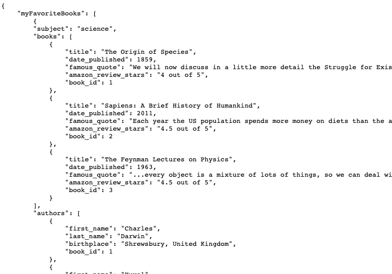

Snapshot of part of the raw JSON file that I created.

#### I used the jsonlite package to read in the json data

```r
books_json_raw <- fromJSON('https://raw.githubusercontent.com/zachalexander/data607_cunysps/master/Homework5/books.json')
```

#### Then, since the data is presented in the form of objects, I was able to isolate the data I needed and saved it to corresponding vectors:

```r
book_json_titles <- books_json_raw$myFavoriteBooks$books[[1]]$title
book_json_dt_pub <- books_json_raw$myFavoriteBooks$books[[1]]$date_published
book_json_famous_quote <- books_json_raw$myFavoriteBooks$books[[1]]$famous_quote
book_json_amazon <- books_json_raw$myFavoriteBooks$books[[1]]$amazon_review_stars

book_json_author_fn <- books_json_raw$myFavoriteBooks$authors[[1]]$first_name
book_json_author_ln <- books_json_raw$myFavoriteBooks$authors[[1]]$last_name
book_json_author_bp <- books_json_raw$myFavoriteBooks$authors[[1]]$birthplace
book_json_num <- paste0('Book ', books_json_raw$myFavoriteBooks$authors[[1]]$book_id)
```

#### After this, I used the same for loop structure to create the extra rows (similar to XML and HTML).

```r
for(i in 4:5){
  book_json_amazon[i] <- book_json_amazon[3]
  book_json_titles[i] <- book_json_titles[3]
  book_json_dt_pub[i] <- book_json_dt_pub[3]
  book_json_famous_quote[i] <- book_json_famous_quote[3]
  book_json_num[i] <- book_json_num[3]
}

# changed the column names one more time to make it more presentable
books_json_df <- data.frame("Book Number" = book_json_num,
                           "Title" = book_json_titles,
                           "Date Published" = book_json_dt_pub,
                           "Famous Quote" = book_json_famous_quote,
                           "Amazon Rating" = book_json_amazon,
                           "Author First Name" = book_json_author_fn,
                           "Author Last Name" = book_json_author_ln,
                           "Author Birthplace" = book_json_author_bp)
```

#### And finally, I printed the final data frame from the JSON data

```r
kable(books_json_df, align = rep('c', 8)) %>%
  kable_styling(bootstrap_options = c("striped"))
```

| Book.Number | Title | Date.Published | Famous.Quote | Amazon.Rating | Author.First.Name | Author.Last.Name | Author.Birthplace |
| --- | --- | --- | --- | --- | --- | --- | --- |
| Book 1 | The Origin of Species | 1859 | We will now discuss in a little more detail the Struggle for Existence. | 4 out of 5 | Charles | Darwin | Shrewsbury, United Kingdom |
| Book 2 | Sapiens: A Brief History of Humankind | 2011 | Each year the US population spends more money on diets than the amount needed to feed all the hungry people in the rest of the world. | 4.5 out of 5 | Yuval | Noah Harari | Kiryat Ata, Israel |
| Book 3 | The Feynman Lectures on Physics | 1963 | …every object is a mixture of lots of things, so we can deal with it only as a series of approximations and idealizations. | 4.5 out of 5 | Richard | Feynman | Queens, New York City |
| Book 3 | The Feynman Lectures on Physics | 1963 | …every object is a mixture of lots of things, so we can deal with it only as a series of approximations and idealizations. | 4.5 out of 5 | Robert | Leighton | Detroit, Michigan |
| Book 3 | The Feynman Lectures on Physics | 1963 | …every object is a mixture of lots of things, so we can deal with it only as a series of approximations and idealizations. | 4.5 out of 5 | Matthew | Sands | Oxford, Massachusetts |